# Framing attributions

A methodological and conceptual contribution to the study of explanations in political text

Paulina García-Corral

PhD dissertation defense

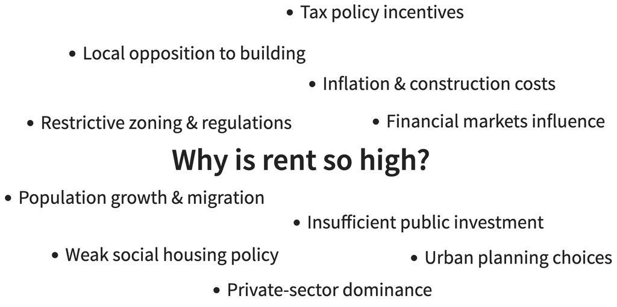

## Introduction

Explanations are fundamental part of the social world.

Overarching theories across paradigms consider why attributing that “A causes B” matters in our understanding of the social world (Stone 1989; Shiller 2019; Entman 1993)

## Examples

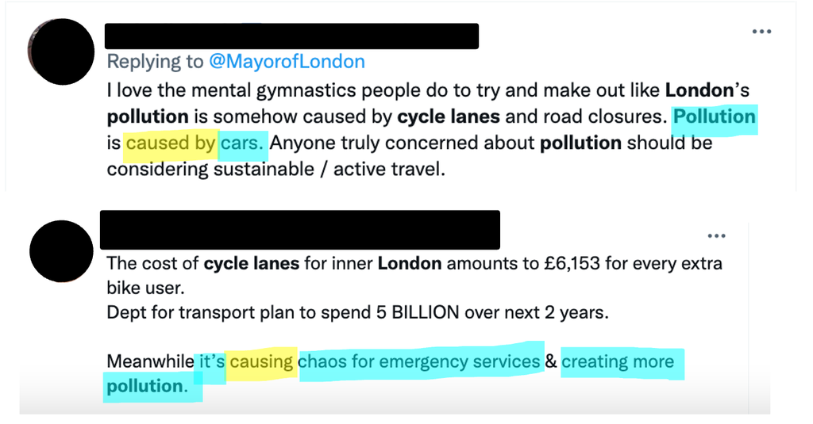

[figure not shown]

## Causal reasoning in politics

Selective attribution helps explain how people assign causes of social issues, and how to solve them (Sahar 2014; Rudolph 2006; McCabe 2016).

In politics, Partisan Motivated Reasoning is the mechanism behind why we tend to assign responsibility for positive outcomes to our own party, while blaming bad outcomes on opponents.

## Causal reasoning in politics

However, attribution is not just a psychological process, but also a discursive practice:

- Politician’s use of justifications can alter accountability (Hansson 2015; Grose, Malhotra, and Parks Van Houweling 2015)
- Media uses causal stories to allocate responsibility and this affects citizens’ blame attributions (Kim 2015; Rozenas and Stukal 2019; Iyengar 1989)
- Elite’s attributions of responsibility influences public attitudes and choices (Hobolt and Tilley 2014; Bisgaard 2015)

## Attributions as empirical objects

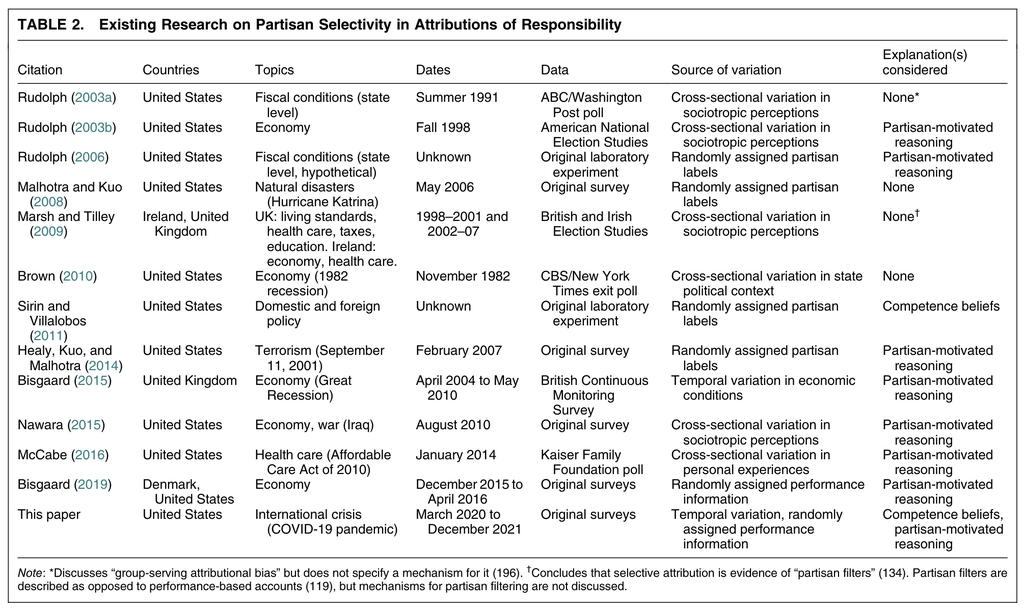

Graham and Singh (2023)

## Attributions as empirical objects

Understanding the mechanisms behind selective attribution is being addressed by improving experimental design (Graham and Singh 2023; Tappin, Pennycook, and Rand 2021).

However, questions of external validity persist.

## Attributions as empirical objects

When analyzing attributions as they are made in political discourse, content analysis relies on domain specific coding.

| Citation | Coding Scheme |
| --- | --- |
| Sotirovic (2003) | Individual vs. Societal |
| Rozenas and Stukal (2019) | National vs. Foreign |
| Hameleers, Bos, and Vreese (2017) | Blame vs. Claim |
| Tilley and Hobolt (2011) | National vs. Regional |
| Hameleers, Bos, and Vreese (2017) | Us vs. Them |

## Attributions as empirical objects

These two approaches have limited the understanding of the broader structure of causal attribution.

We need a general, scalable method to answer the question:

> *“who is claiming what and about whom?”*

## How to measure attributions?

Text-as-data methods are well-suited to capture discursive objects in natural occurring text data.

Causal Language Modeling (CLM) offers a systematic approach to identifying and analyzing causal claims.

## Research question

**Methodological:**

> **How can causal attributions be used to empirically study political discourse?**

**Conceptual:**

> **How are causal attribution employed in media framing?**

## Challenges

- Causal language is very hard to model.
- CLM has not been tested in political text data.
- Rhetorical, strategic, and often contested, and highly contextual.
- Consensus about basic causal stories is fragmented.
- The task is not to determine if statements are true, but to parse as expressed.

## Operationalize attributions

Break down causal attributions to its linguistic components

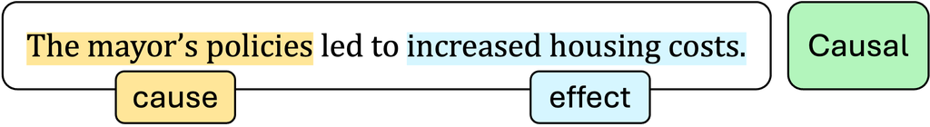

And get structured data from unstructured text

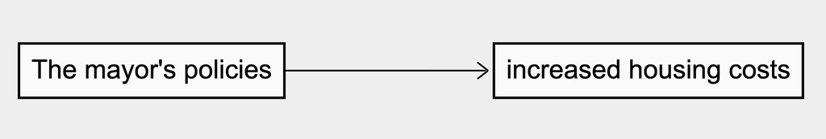

## Instrumentalize attributions

Causal Language Modeling:

- Define what causal language looks like in text
  - Annotation codebook
  - Corpus creation
- Train a model to capture these expressions
  - Classification and Span Detection tasks

## PolitiCAUSE

- First corpus of political text annotated for causality (Corral et al. 2024).
- Annotated ~18,000 sentences of the UNGD corpus (Jankin, Baturo, and Dasandi 2017).

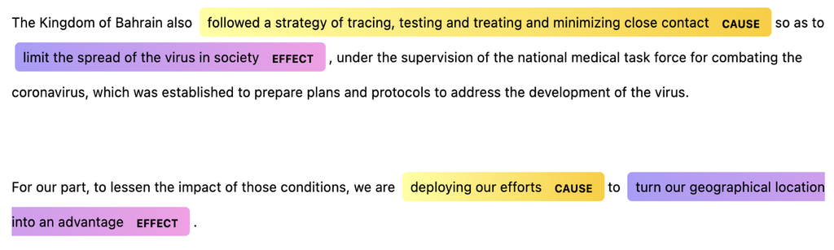

## PolitiCAUSE results

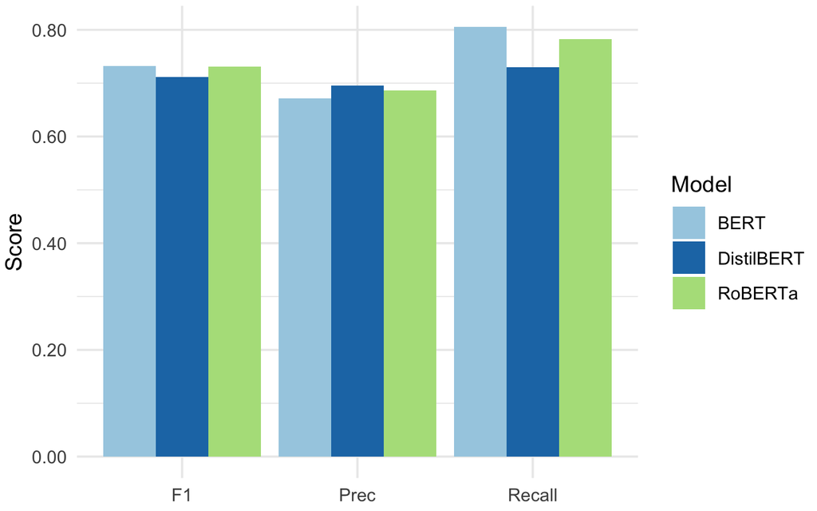

## Large Language Models

Larger contexts promise better performance.

This raises a memorization v.s. generalization question between linguistic cues and causal mechanisms (Kıcıman et al. 2023; Hobbhahn, Lieberum, and Seiler 2022; Takayanagi et al. 2024).

## Large Language Models

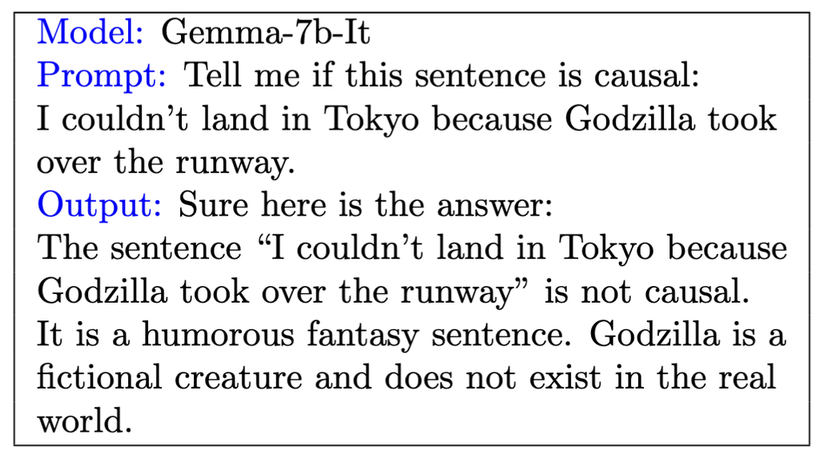

## Large Language Models Evaluation

Designed an evaluation to determine if models can parse causal expressions: Linguistic Causal Disambiguation.

Used adversarial testing to begin understanding the mechanism used to perform a “causal classification” task when using token generation.

## Large Language Models results

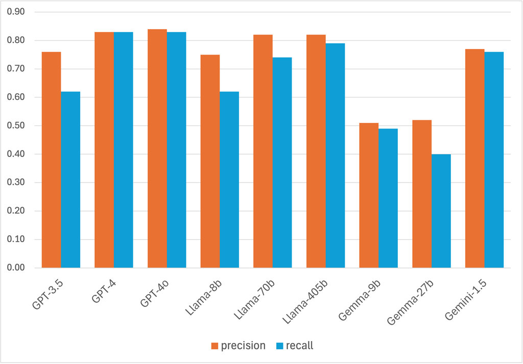

## Lessons learned: Language Modeling

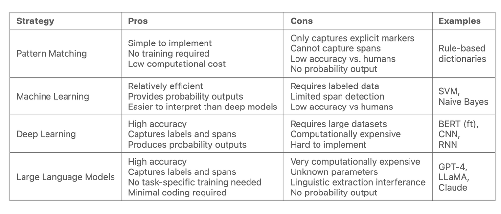

## As a method for political analysis

Causal Language Modeling Framework for the study of attribution in political discourse.

Transformer-based models provide a balance between transferability, scalability, and accuracy with modest training data needs.

Provide a probabilistic output perfect for downstream analysis

## Method

1. BERT (Devlin et al. 2018) for Sequence Classification

[figure not shown]

2. BERT for Information Extraction

[figure not shown]

## Probabilistic outcomes

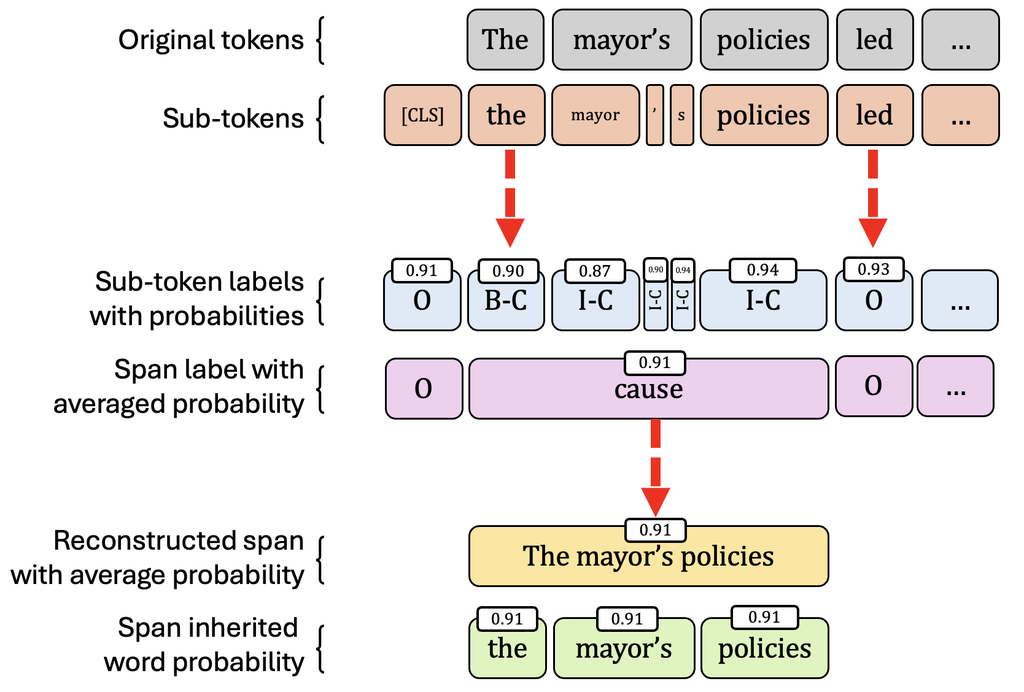

## Strengths and opportunities

- Adaptable for specific constructions.
- Flexible to model choice.
- Downstream analysis agnostic.
- Based on semantics.
- Annotation is cognitively taxing.
- Sensitive to preprocessing choices.
- Computational requirements.

## Application: Media frames

Causal attributions are seldom operationalized as frames, despite being central to the theory (Entman 1993).

Using causal attributions as frames, I seek answer the question:

> **How are causal attribution employed in media framing?**

To answer this question, I propose non-attribution as a unique strategy.

## Non-attribution

Events that have a known cause and a known outcome such as:

| Event 1 | $\rightarrow$ | Event 2 |
| --- | --- | --- |
| Russian strike | causes | 20 people are not alive anymore |

## Non-attribution

| cause event $\rightarrow$ effect event | explicit causal | 20 killed in Kharkiv strike by Russia. |
| --- | --- | --- |
| $\otimes$ $\rightarrow$ effect event | cause implicit | 20 killed in Kharkiv. |
| event - event | outcome implicit | 20 dead in strike. |

## Case study: Corpus and data

- AJ, BBC and CNN
- October 2023 to June 2025

| Region | Source | Count (Proportion) |
| --- | --- | --- |
| ME | AJ | 1994 (0.29) |
|  | BBC | 2781 (0.41) |
|  | CNN | 2017 (0.30) |
| EE | AJ | 3603 (0.39) |
|  | BBC | 2625 (0.29) |
|  | CNN | 2962 (0.32) |

## Causal Language Model ft. on news corpus

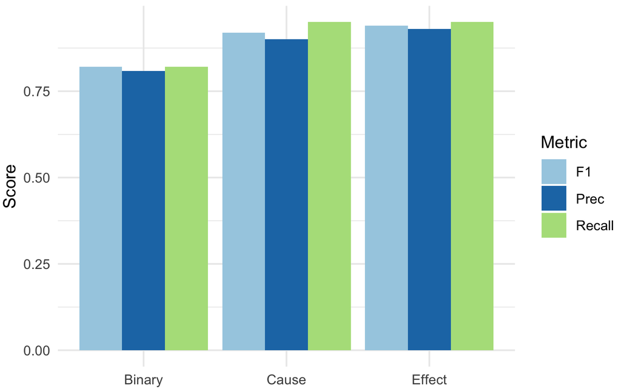

## Is there a difference in use of causal headlines?

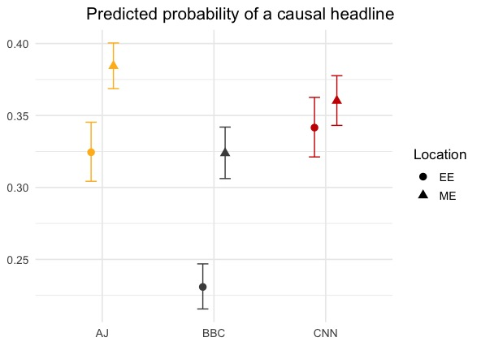

## How is causality assigned across actors?

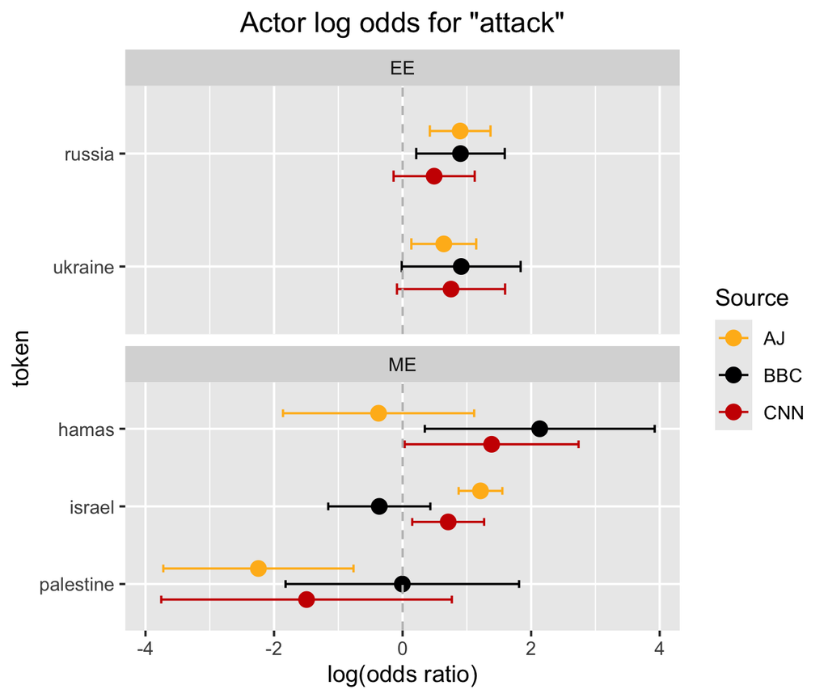

## Observable Implications

|  | Regime | Citation | Finding |
| --- | --- | --- | --- |
| State | Autocratic | Rozenas and Stukal (2019) | Selective attribution serves to explain social material issues. |
| Private | Democratic | Iyengar (1987) | Selective attribution serves as partisan filtering of events |
| PSM | Democratic |  | *Neutrality performance under soft political power?* |

## Conclusions

Methodological: How can causal attributions be used to empirically study political discourse?

Theoretical: How are causal attribution strategically used in media framing?

- **Non-attribution as a framing strategy**

By advancing a methodological question I show how we can extend theory of framing and attribution.

## My contributions

- **Create a corpus** **and annotation scheme** to detect causal attributions in political text.
- **Develop an evaluation framework** for causal language extraction for LMs.
- **Introduce a supervised, NLP-based framework** to identify and measure causal attributions in political texts.
- **Analyze how attributions are used in media and present non-attribution** as a framing strategy for neutrality performance.

## Thank you

Paulina García-Corral

corral@hertie-school.org

[figure not shown]

[figure not shown]

## Appendix

## Paper 1: Background

| Dataset | Citation | Description |
| --- | --- | --- |
| BeCAUSE 2.0 | Dunietz (n.d.) | 5,380 based on construction grammar, newspaper articles, PDT, and US congress. |
| Parallel Wikipedia Corpus | Hidey and McKeown (2016) | 265,627 Wikipedia based on alternative lexicalizations. |
| Causal-TimeBank | Mirza et al. (2014) | TempEval-3 task + causal singals and links. |
| EventStoryLine Corpus | Caselli and Vossen (2017) | 258 documents temporal and causal language of stories |
| Causal News Corpus | Tan et al. (2022) | 3,559 events from protest news. |
| Unicausal | Tan, Zuo, and Ng (2023) | 58,720 sentences from different datasets |
| Chemical Induced Disease | Gu, Qian, and Zhou (2016) | Relation extraction for drugs and adverse effects |
| FinCausal | Mariko et al. (n.d.) | Financial documents for causal extraction |
| PubMed Corpus | Yu, Li, and Wang (n.d.) | 3,000 research conclusion sentences for correlational v causal language |
| e-CARE | Du et al. (2022) | question answering task dataset |

## Paper 1: Corpus

**Corpus composition**

|  |  | tokens (word-level) |  |
| --- | --- | --- | --- |
|  | **N** | **mean** | **std** |
| UNGD | 8,872 | 2,702.87 | 1,357.05 |
| UK Press | 429 | 787.78 | 477.58 |

**Finetuning**

|  | Total | Not Causal | Causal |
| --- | --- | --- | --- |
| train | 12,446 | 8,897 | 3,549 |
| val | 2,667 | 1,906 | 761 |
| test | 2,667 | 1,906 | 760 |

## Paper 1: Results

|  | BERT | RoBERTa | DistilBERT | UniCausal |
| --- | --- | --- | --- | --- |
| Acc | 0.832 | 0.836 | 0.832 | 0.715 |
| Prec | 0.671 | 0.686 | 0.696 | 0.500 |
| Recall | 0.805 | 0.783 | 0.730 | 0.612 |
| MCC | 0.617 | 0.617 | 0.594 | 0.550 |
| F1 | 0.732 | 0.731 | 0.712 | 0.349 |

## Paper 1: Error Analysis

|  | Full Corpus |  | Error Subset |  |
| --- | --- | --- | --- | --- |
| Label | TN | TP | FN | FP |
| Mean conf | 4.63 | 4.13 | 4.20 | 4.30 |
| Maj label | 0.79 | 0.10 | 0.71 | 0.26 |
| Mean len | 26.13 | 31.73 | 30.10 | 31.35 |
| Causal conn | 0.37 | 0.50 | 0.44 | 0.48 |

## Paper 1: Discussion

- Explicit causal sentences only: Implicit structures are also rhetorical and possibly intentional.
- Single sentence causal structures: Causal attributions also exist across sentences.
- Corpus external validity from UN debates: Elite rhetoric, audience is other elites, prepared.

## Paper 2: Background

| Citation | Model | Findings |
| --- | --- | --- |
| Takayanagi et al. (2024) | ChatGPT | baseline proficency, but can be outperformed by smaller LM |
| Hobbhahn, Lieberum, and Seiler (2022) | GPT-3 | Importance of prompting |
| Gao et al. (2023) | ChatGPT | Can provide causal explanations but reasoning is unclear |
| Kıcıman et al. (2023) | GPT-3 | Outperforms in causal reasoning tasks |
| Ho et al. (2022) | GPT-3 | Low rating for cause-effect pair matching |
| Jin et al. (2024) | Llama, Alpaca, GPT | High performance for causal stories |

## Paper 2: Corpus and data

| Data | N | Text |
| --- | --- | --- |
| PolitiCAUSE | 527 | mostly UNGD |
| Fake news | 50 | multiple fake news detection databases |
| Post-train date | 50 | LexisNexis news databases |

## Paper 2: Experimental design

### Prompt

System: You are a causal language model that performs causal sequence classification and causal span detection. You will classify a text as causal or not causal, and if it’s causal you will extract the causes and effects. The output should be a json with label 1 or 0, cause, and effect value such as {”label”:, ”cause”: ,”effect”: }.

User: But to pay for it, we had to take on debt, precipitated by massive reduction in Government revenue.

Assistant:{”label”: 1,”cause”: ”massive reduction in Government revenue”,  
n ”effect”: ”had to take on debt”}

#### Models

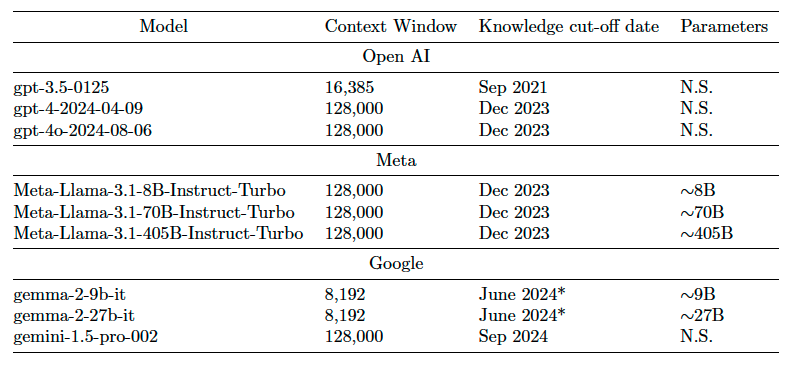

#### Model parameters

| Parameter | Value |
| --- | --- |
| Temperature | 0.0 |
| Top p: | 1.0 |
| Top k: | 1.0 |
| Frequency penalty | 0.0 |
| Presence pentaly | 0.0 |
| Repetition penalty | 0.0 |
| Max body tokens | 200 |

#### Inference

- All Open AI models were run using the Open AI Batch API.
- Llama and Gemma models were accessed via the Transformers library from Hugging Face, and inference was run using the Together AI API.
- Gemini-1.5 was run using Google’s AI Studio API.
- For Google models, the HarmBlockThreshold in the safety settings parameter was set to None for the first two experiments, and set to default for the Fake news and post-training events set of sentences in LCD evaluation.

## Paper 2: Results

#### PolitiCAUSE Causal Sequence Classification results.

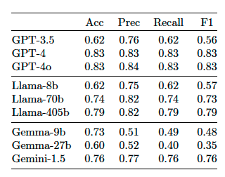

#### LCD Causal Sequence Classification results for Fake News and Post-training events sentence sets.

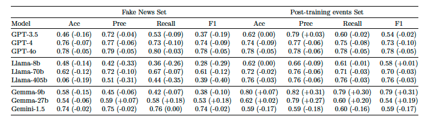

## Paper 2: Error Analysis

Model’s with more parameters exhibit better performance overall:

- Following recall and precision smaller models may be relying on more explicit causal markers, while larger models can “infer from context”.
- Scale contributes not only to broader generalization, but also to more faithful alignment with syntactic and semantic cues in discourse.
- Smaller models appear more susceptible to heuristic pattern matching and are prone to overgeneralizing causal signals from pretraining data.

## Paper 2: Discussion

- PolitiCAUSE contains extensive but noisy data, so only the highest-quality, human-verified sentences were used to ensure reliable evaluation and avoid cases where human annotations might be wrong.
- The prompt follows established structures from prior work to maximize stability in zero-shot settings, acknowledging that alternative prompting strategies (e.g., Chain of Thought) could also work.
- Although paraphrasing can also show correct causal structure identification, the experiment required outputs in a consistent, easily parseable format for downstream applications.
- Identifying claims relies on linguistic cues separate from truthfulness, and the study assumes models should do the same; observed safety behaviors and genre effects suggest that even with similar training data, LLMs still conflate real vs. fake content.

## Paper 3: Background

- Causal Language Models (Tan, Zuo, and Ng 2023; Drury, Gonçalo Oliveira, and Andrade Lopes 2022)
- Attribution work more broadly (Sotirovic 2003; Rozenas and Stukal 2019, 2019; Hameleers, Bos, and Vreese 2017, 2017; Tilley and Hobolt 2011; Graham and Singh 2023; Malhotra and Kuo 2008; Iyengar 1987)

## Paper 3: Set up

### Causal Sequence Classification

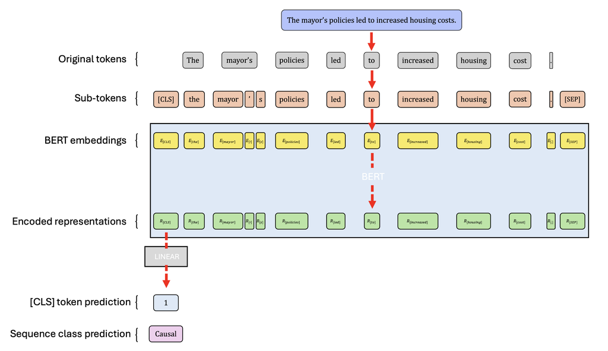

### Causal Span Detection

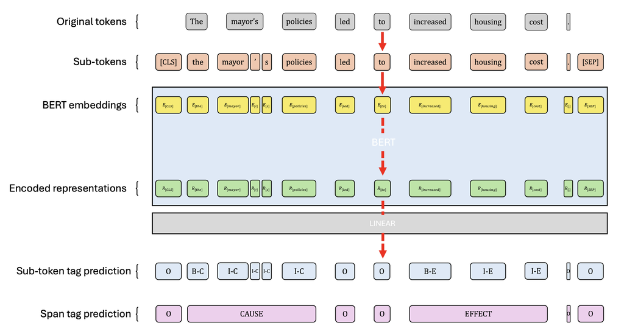

## Paper 3: Training specifications

#### Corpus

- AJ, BBC and CNN
- May 2023 to February 2024

| Region | Source | Count (Proportion) |
| --- | --- | --- |
| ME | AJ | 1251 (0.48) |
|  | BBC | 792 (0.30) |
|  | CNN | 567 (0.22) |
| EE | AJ | 1018 (0.43) |
|  | BBC | 784 (0.33) |
|  | CNN | 581 (0.24) |

#### Training splits

| Set | Count (Proportion) |
| --- | --- |
| Train | 862 (0.70) |
| Test | 191 (0.15) |
| Validation | 185 (0.15) |
| Total | 1238 (1.00) |

#### Datasets

🤗 pgarco/CausalPalUkr_Train_Test

🤗 pgarco/CausalPalUkr_Val.

#### Models

🤗 pgarco/CausalPalUkr_token

🤗 pgarco/CausalPalUkr_seq

#### Model metrics

|  | Precision | Recall | Accuracy | F1-score |
| --- | --- | --- | --- | --- |
| CAUSAL | 0.891 | 0.855 |  | 0.872 |
| NOT CAUSAL | 0.727 | 0.787 |  | 0.756 |
| weighted average | 0.837 | 0.832 | 0.832 | 0.834 |

## Paper 3: Validation

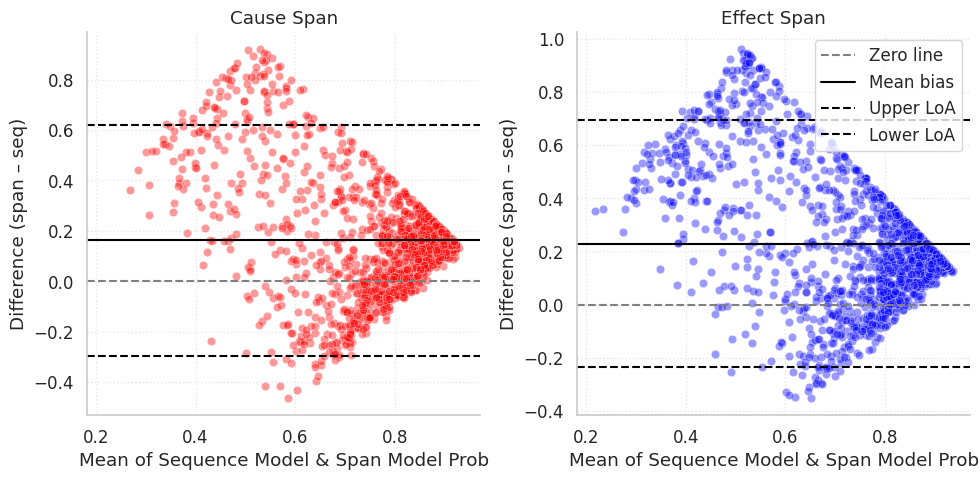

## Paper 3: Results

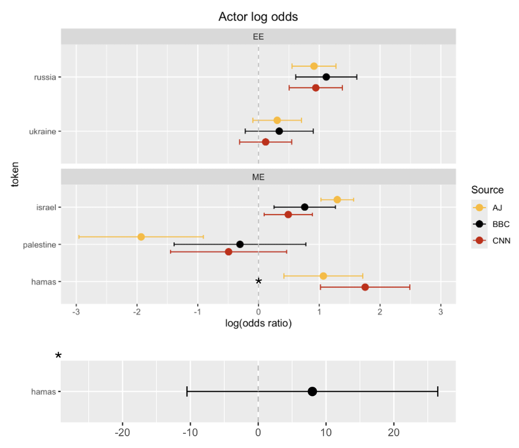

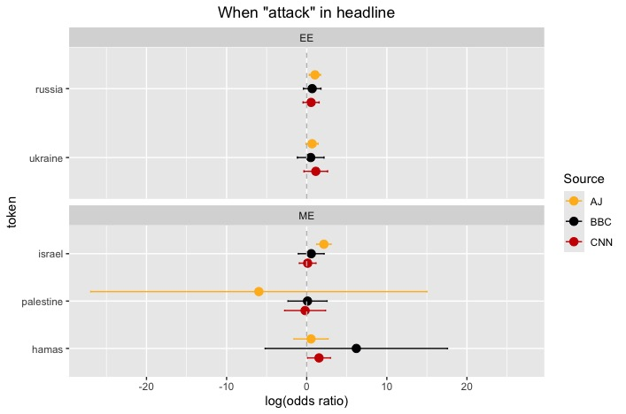

## Paper 3: Discussion

- Model Selection: Model agnostic and potential to include LLMs
- Annotation rules can be further detailed for specific cases
- Additional information due to a known semantic relationship

## Paper 4: Background

- Selective attribution always works under the assumption of framing works as a competitions between actors (Iyengar 1987; Rozenas and Stukal 2019; Bisgaard 2015)
- Media bias has also shown the omission can also affect responsibility (Gentzkow and Shapiro 2006) .

## Paper 4: Operationalization

| Causal with responsibility | Causal without responsibility |
| --- | --- |
| Officials report indicent in Kharkiv. | Officials report incident in Kharkiv kills 20. |

| Agentless with overall ambiguity | Agentless with precise outcome |
| --- | --- |
| Officials report incdent in Kharkic. | Officials report incident in Kharkiv kills 20. |

| Non-attribution by supression | Non-attribution by predicate change |
| --- | --- |
| 20 killed in Kharkiv strike. | Officials in Kharkic report 20 dead. |

## Paper 4: Corpus and data

- AJ, BBC and CNN
- October 2023 to June 2025

| Region | Source | Count (Proportion) |
| --- | --- | --- |
| ME | AJ | 1994 (0.29) |
|  | BBC | 2781 (0.41) |
|  | CNN | 2017 (0.30) |
| EE | AJ | 3603 (0.39) |
|  | BBC | 2625 (0.29) |
|  | CNN | 2962 (0.32) |

## Paper 4: Agent Annotation

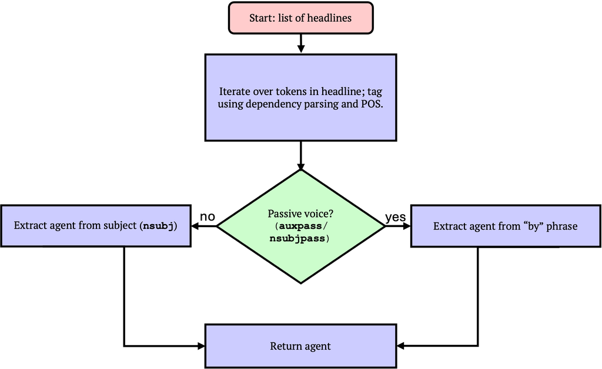

## Paper 4: Results

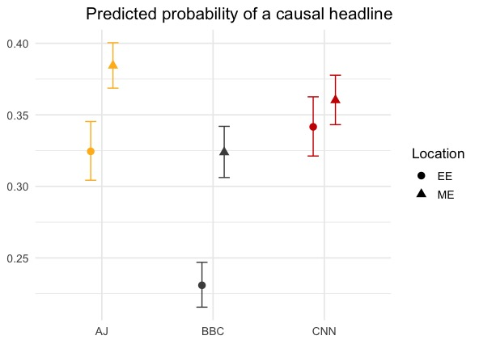

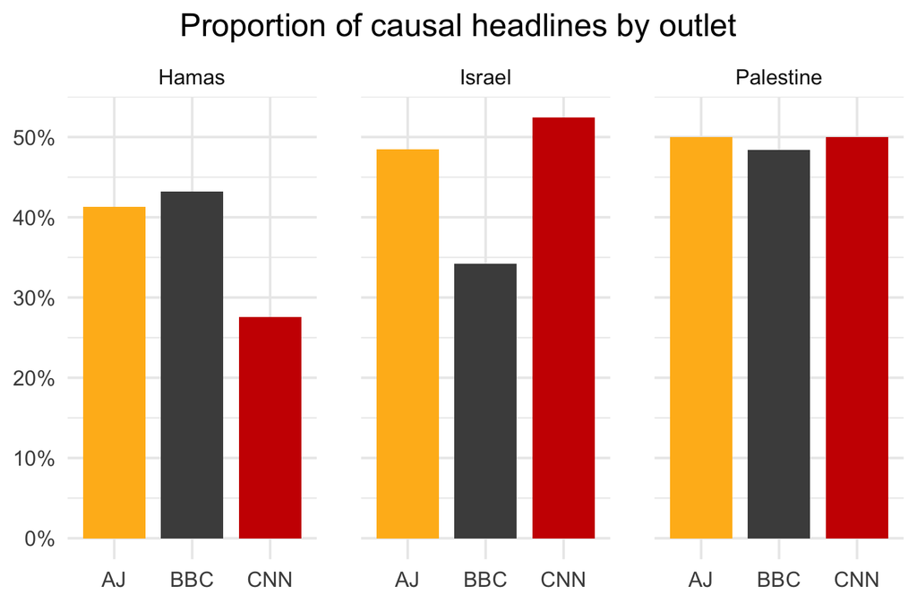

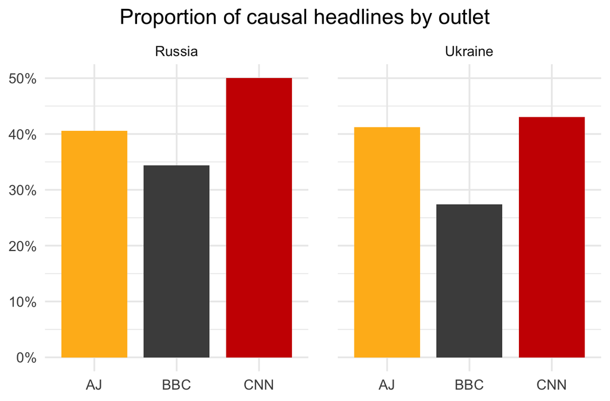

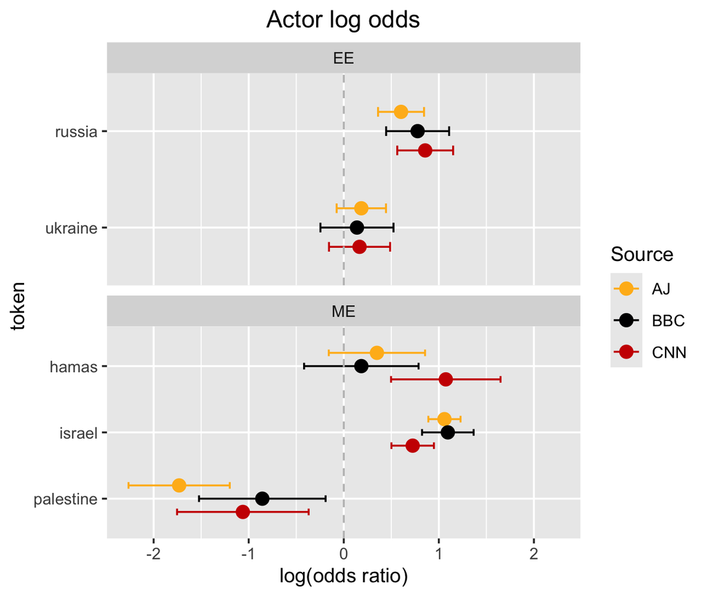